# Assignment 04: Tidy data and joins

Diana Lin

## Set Up

Load required packages:

```r
suppressMessages(library(tidyverse))
suppressMessages(library(gapminder))
suppressMessages(library(DT))
```

## Exercise 1: Univariate Data Reshaping

Choose **EITHER** “Univariate Option 1” or “Univariate Option 2”. Both of these problems have three components:

1. Putting data in wider format;
2. Producing a plot of the wide data;
3. Re-lengthening the wider data.

You are expected to use `pivot_wider()` and `pivot_longer()` for reshaping, and ggplot2 for the plot.

Regarding the plot:

- Don’t worry about plotting all of the data from the wide tibble.
- The plot should be something that someone might actually want to produce in an analysis.

### Univariate Option 1

#### 1. Make a tibble with one row per year, and columns for life expectancy for two or more countries.

```r
widened <- gapminder %>%
  pivot_wider(id_cols = year, names_from = "country", values_from = lifeExp)
```

- Each row in this table corresponds to a single year, and there is a column for each of the 142 countries containing the life expectancy in years.
- There is a total of only 12 rows in this `tibble`, as there are only 12 years in the gapminder data set.

##### **NOTE**: this datatable can be scrolled **horizontally** to reveal *more* columns!

| year | Afghanistan | Albania | Algeria | Angola | Argentina | Australia | Austria | Bahrain | Bangladesh | Belgium | Benin | Bolivia | Bosnia and Herzegovina | Botswana | Brazil | Bulgaria | Burkina Faso | Burundi | Cambodia | Cameroon | Canada | Central African Republic | Chad | Chile | China | Colombia | Comoros | Congo, Dem. Rep. | Congo, Rep. | … |
| --- | --- | --- | --- | --- | --- | --- | --- | --- | --- | --- | --- | --- | --- | --- | --- | --- | --- | --- | --- | --- | --- | --- | --- | --- | --- | --- | --- | --- | --- | --- |
| 1952 | 28.801 | 55.23 | 43.077 | 30.015 | 62.485 | 69.12 | 66.8 | 50.939 | 37.484 | 68 | 38.223 | 40.414 | 53.82 | 47.622 | 50.917 | 59.6 | 31.975 | 39.031 | 39.417 | 38.523 | 68.75 | 35.463 | 38.092 | 54.745 | 44 | 50.643 | 40.715 | 39.143 | 42.111 | … |
| 1957 | 30.332 | 59.28 | 45.685 | 31.999 | 64.399 | 70.33 | 67.48 | 53.832 | 39.348 | 69.24 | 40.358 | 41.89 | 58.45 | 49.618 | 53.285 | 66.61 | 34.906 | 40.533 | 41.366 | 40.428 | 69.96 | 37.464 | 39.881 | 56.074 | 50.54896 | 55.118 | 42.46 | 40.652 | 45.053 | … |
| 1962 | 31.997 | 64.82 | 48.303 | 34 | 65.142 | 70.93 | 69.54 | 56.923 | 41.216 | 70.25 | 42.618 | 43.428 | 61.93 | 51.52 | 55.665 | 69.51 | 37.814 | 42.045 | 43.415 | 42.643 | 71.3 | 39.475 | 41.716 | 57.924 | 44.50136 | 57.863 | 44.467 | 42.122 | 48.435 | … |
| 1967 | 34.02 | 66.22 | 51.407 | 35.985 | 65.634 | 71.1 | 70.14 | 59.923 | 43.453 | 70.94 | 44.885 | 45.032 | 64.79 | 53.298 | 57.632 | 70.42 | 40.697 | 43.548 | 45.415 | 44.799 | 72.13 | 41.478 | 43.601 | 60.523 | 58.38112 | 59.963 | 46.472 | 44.056 | 52.04 | … |
| 1972 | 36.088 | 67.69 | 54.518 | 37.928 | 67.065 | 71.93 | 70.63 | 63.3 | 45.252 | 71.44 | 47.014 | 46.714 | 67.45 | 56.024 | 59.504 | 70.9 | 43.591 | 44.057 | 40.317 | 47.049 | 72.88 | 43.457 | 45.569 | 63.441 | 63.11888 | 61.623 | 48.944 | 45.989 | 54.907 | … |
| 1977 | 38.438 | 68.93 | 58.014 | 39.483 | 68.481 | 73.49 | 72.17 | 65.593 | 46.923 | 72.8 | 49.19 | 50.023 | 69.86 | 59.319 | 61.489 | 70.81 | 46.137 | 45.91 | 31.22 | 49.355 | 74.21 | 46.775 | 47.383 | 67.052 | 63.96736 | 63.837 | 50.939 | 47.804 | 55.625 | … |
| 1982 | 39.854 | 70.42 | 61.368 | 39.942 | 69.942 | 74.74 | 73.18 | 69.052 | 50.009 | 73.93 | 50.904 | 53.859 | 70.69 | 61.484 | 63.336 | 71.08 | 48.122 | 47.471 | 50.957 | 52.961 | 75.76 | 48.295 | 49.517 | 70.565 | 65.525 | 66.653 | 52.933 | 47.784 | 56.695 | … |
| 1987 | 40.822 | 72 | 65.799 | 39.906 | 70.774 | 76.32 | 74.94 | 70.75 | 52.819 | 75.35 | 52.337 | 57.251 | 71.14 | 63.622 | 65.205 | 71.34 | 49.557 | 48.211 | 53.914 | 54.985 | 76.86 | 50.485 | 51.051 | 72.492 | 67.274 | 67.768 | 54.926 | 47.412 | 57.47 | … |
| 1992 | 41.674 | 71.581 | 67.744 | 40.647 | 71.868 | 77.56 | 76.04 | 72.601 | 56.018 | 76.46 | 53.919 | 59.957 | 72.178 | 62.745 | 67.057 | 71.19 | 50.26 | 44.736 | 55.803 | 54.314 | 77.95 | 49.396 | 51.724 | 74.126 | 68.69 | 68.421 | 57.939 | 45.548 | 56.433 | … |
| 1997 | 41.763 | 72.95 | 69.152 | 40.963 | 73.275 | 78.83 | 77.51 | 73.925 | 59.412 | 77.53 | 54.777 | 62.05 | 73.244 | 52.556 | 69.388 | 70.32 | 50.324 | 45.326 | 56.534 | 52.199 | 78.61 | 46.066 | 51.573 | 75.816 | 70.426 | 70.313 | 60.66 | 42.587 | 52.962 | … |

[output cut: 2 more lines]

#### 2. Take advantage of this new data shape to scatterplot life expectancy for one country against that of another.

```r
widened_plot <- widened %>%
  ggplot(aes(Canada, China)) +
  geom_point(aes(color = as.factor(year))) +
  ggtitle("Life Expectancy from 1952 to 2007") +
  ylab("Life Expectancy in China (years)") +
  xlab("Life Expectancy in Canada (years)") +
  scale_color_discrete("Year") +
  theme(text = element_text(size=18))
```

- China consistently has a lower life expectancy than Canada in every year.
- Both countries have a steadily increasing life expectancy overall, except for China in 1962, where the China’s life expectancy dropped substantially.

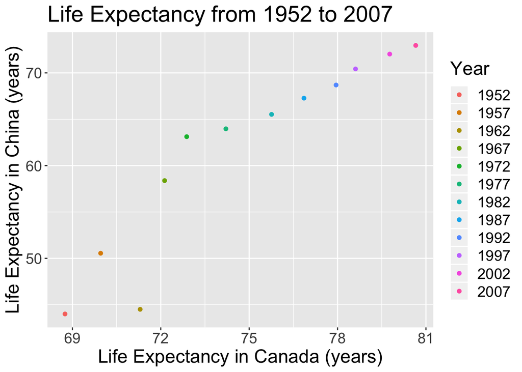

#### 3. Re-lengthen the data.

```r
lengthened <- widened %>%
  pivot_longer(cols = -year, names_to = "country", values_to = "lifeExp")
```

- The relengthened `tibble` will *only* contain `year`, `country`, `lifeExp` (since the other columns `continent`, `gdpPercap` and `pop` were dropped during the original `pivot_wider()`), with each combination of `country` and `year` in each row.

| year | country | lifeExp |
| --- | --- | --- |
| 1952 | Afghanistan | 28.801 |
| 1952 | Albania | 55.23 |
| 1952 | Algeria | 43.077 |
| 1952 | Angola | 30.015 |
| 1952 | Argentina | 62.485 |
| 1952 | Australia | 69.12 |
| 1952 | Austria | 66.8 |
| 1952 | Bahrain | 50.939 |
| 1952 | Bangladesh | 37.484 |
| 1952 | Belgium | 68 |

[output cut: 1694 more lines]

## Exercise 2: Multivariate Data Reshaping

Choose **EITHER** “Multivariate Option 1” or “Multivariate Option 2”. All of these problems have two components:

1. Putting data in wider format;
2. Re-lengthening the data.

Don’t worry about producing a plot here. You are expected to use `pivot_wider()` and `pivot_longer()` for reshaping.

### Multivariate Option 1

#### 1. Make a tibble with one row per year, and columns for life expectancy and GDP per capita (or two other numeric variables) for two or more countries.

```r
widened <- gapminder %>%
  pivot_wider(id_cols  = year,
              names_from = country,
              names_sep = "_",
              values_from = c("lifeExp", "gdpPercap"))
```

- This widened `tibble` contains a column for `lifeExp` and `gdpPercap` of all 142 countries for each row, meaning a total of 285 columns.
- This `tibble` has 12 rows, as that is the number of unique years in the `gapminder` dataset.

##### **NOTE**: this datatable can be scrolled **horizontally** to reveal *more* columns!

| year | lifeExp_Afghanistan | lifeExp_Albania | lifeExp_Algeria | lifeExp_Angola | lifeExp_Argentina | lifeExp_Australia | lifeExp_Austria | lifeExp_Bahrain | lifeExp_Bangladesh | lifeExp_Belgium | lifeExp_Benin | lifeExp_Bolivia | lifeExp_Bosnia and Herzegovina | lifeExp_Botswana | lifeExp_Brazil | lifeExp_Bulgaria | lifeExp_Burkina Faso | lifeExp_Burundi | lifeExp_Cambodia | lifeExp_Cameroon | lifeExp_Canada | lifeExp_Central African Republic | lifeExp_Chad | lifeExp_Chile | lifeExp_China | lifeExp_Colombia | lifeExp_Comoros | lifeExp_Congo, Dem. Rep. | lifeExp_Congo, Rep. | … |
| --- | --- | --- | --- | --- | --- | --- | --- | --- | --- | --- | --- | --- | --- | --- | --- | --- | --- | --- | --- | --- | --- | --- | --- | --- | --- | --- | --- | --- | --- | --- |
| 1952 | 28.801 | 55.23 | 43.077 | 30.015 | 62.485 | 69.12 | 66.8 | 50.939 | 37.484 | 68 | 38.223 | 40.414 | 53.82 | 47.622 | 50.917 | 59.6 | 31.975 | 39.031 | 39.417 | 38.523 | 68.75 | 35.463 | 38.092 | 54.745 | 44 | 50.643 | 40.715 | 39.143 | 42.111 | … |
| 1957 | 30.332 | 59.28 | 45.685 | 31.999 | 64.399 | 70.33 | 67.48 | 53.832 | 39.348 | 69.24 | 40.358 | 41.89 | 58.45 | 49.618 | 53.285 | 66.61 | 34.906 | 40.533 | 41.366 | 40.428 | 69.96 | 37.464 | 39.881 | 56.074 | 50.54896 | 55.118 | 42.46 | 40.652 | 45.053 | … |
| 1962 | 31.997 | 64.82 | 48.303 | 34 | 65.142 | 70.93 | 69.54 | 56.923 | 41.216 | 70.25 | 42.618 | 43.428 | 61.93 | 51.52 | 55.665 | 69.51 | 37.814 | 42.045 | 43.415 | 42.643 | 71.3 | 39.475 | 41.716 | 57.924 | 44.50136 | 57.863 | 44.467 | 42.122 | 48.435 | … |
| 1967 | 34.02 | 66.22 | 51.407 | 35.985 | 65.634 | 71.1 | 70.14 | 59.923 | 43.453 | 70.94 | 44.885 | 45.032 | 64.79 | 53.298 | 57.632 | 70.42 | 40.697 | 43.548 | 45.415 | 44.799 | 72.13 | 41.478 | 43.601 | 60.523 | 58.38112 | 59.963 | 46.472 | 44.056 | 52.04 | … |
| 1972 | 36.088 | 67.69 | 54.518 | 37.928 | 67.065 | 71.93 | 70.63 | 63.3 | 45.252 | 71.44 | 47.014 | 46.714 | 67.45 | 56.024 | 59.504 | 70.9 | 43.591 | 44.057 | 40.317 | 47.049 | 72.88 | 43.457 | 45.569 | 63.441 | 63.11888 | 61.623 | 48.944 | 45.989 | 54.907 | … |
| 1977 | 38.438 | 68.93 | 58.014 | 39.483 | 68.481 | 73.49 | 72.17 | 65.593 | 46.923 | 72.8 | 49.19 | 50.023 | 69.86 | 59.319 | 61.489 | 70.81 | 46.137 | 45.91 | 31.22 | 49.355 | 74.21 | 46.775 | 47.383 | 67.052 | 63.96736 | 63.837 | 50.939 | 47.804 | 55.625 | … |
| 1982 | 39.854 | 70.42 | 61.368 | 39.942 | 69.942 | 74.74 | 73.18 | 69.052 | 50.009 | 73.93 | 50.904 | 53.859 | 70.69 | 61.484 | 63.336 | 71.08 | 48.122 | 47.471 | 50.957 | 52.961 | 75.76 | 48.295 | 49.517 | 70.565 | 65.525 | 66.653 | 52.933 | 47.784 | 56.695 | … |
| 1987 | 40.822 | 72 | 65.799 | 39.906 | 70.774 | 76.32 | 74.94 | 70.75 | 52.819 | 75.35 | 52.337 | 57.251 | 71.14 | 63.622 | 65.205 | 71.34 | 49.557 | 48.211 | 53.914 | 54.985 | 76.86 | 50.485 | 51.051 | 72.492 | 67.274 | 67.768 | 54.926 | 47.412 | 57.47 | … |
| 1992 | 41.674 | 71.581 | 67.744 | 40.647 | 71.868 | 77.56 | 76.04 | 72.601 | 56.018 | 76.46 | 53.919 | 59.957 | 72.178 | 62.745 | 67.057 | 71.19 | 50.26 | 44.736 | 55.803 | 54.314 | 77.95 | 49.396 | 51.724 | 74.126 | 68.69 | 68.421 | 57.939 | 45.548 | 56.433 | … |
| 1997 | 41.763 | 72.95 | 69.152 | 40.963 | 73.275 | 78.83 | 77.51 | 73.925 | 59.412 | 77.53 | 54.777 | 62.05 | 73.244 | 52.556 | 69.388 | 70.32 | 50.324 | 45.326 | 56.534 | 52.199 | 78.61 | 46.066 | 51.573 | 75.816 | 70.426 | 70.313 | 60.66 | 42.587 | 52.962 | … |

[output cut: 2 more lines]

#### 2. Re-lengthen the data.

```r
lengthened <- widened %>%
  pivot_longer(cols = -year,
               names_to = c(".value", "country"),
               names_sep = "_")
```

- The relengthened `tibble` below will *only* contain `year`, `country`, `lifeExp` and `gdpPercap` (since the other columns `continent` and `pop` were dropped during the original `pivot_wider()`), with each combination of `country` and `year` in each row.

| year | country | lifeExp | gdpPercap |
| --- | --- | --- | --- |
| 1952 | Afghanistan | 28.801 | 779.4453145 |
| 1952 | Albania | 55.23 | 1601.056136 |
| 1952 | Algeria | 43.077 | 2449.008185 |
| 1952 | Angola | 30.015 | 3520.610273 |
| 1952 | Argentina | 62.485 | 5911.315053 |
| 1952 | Australia | 69.12 | 10039.59564 |
| 1952 | Austria | 66.8 | 6137.076492 |
| 1952 | Bahrain | 50.939 | 9867.084765 |
| 1952 | Bangladesh | 37.484 | 684.2441716 |
| 1952 | Belgium | 68 | 8343.105127 |

[output cut: 1694 more lines]

## Exercise 3: Table Joins

Do **ALL** of the activities in this section.

Read in the made-up wedding guestlist and email addresses using the following lines (go ahead and copy-paste these):

```r
guest <- suppressMessages(
  read_csv("https://raw.githubusercontent.com/STAT545-UBC/Classroom/master/data/wedding/attend.csv")
  )

email <- suppressMessages(
  read_csv("https://raw.githubusercontent.com/STAT545-UBC/Classroom/master/data/wedding/emails.csv")
  )
```

Then, complete the following tasks using the `tidyverse` (`tidyr`, `dplyr`, …). No need to do any pivoting – feel free to leave `guest` in its current format.

### Exercise 3.1

#### For each guest in the guestlist (`guest` tibble), add a column for email address, which can be found in the `email` tibble.

- In order to join these two tibbles, the `email` tibble must be separated by guest as opposed to by party, using `separate_rows()`.
- Then, the guest column in `email` must be renamed to `name`, as it appears in the `guest` tibble, using `rename()`.

```r
email_sep <- email %>%
  separate_rows(email, guest, sep = ", ") %>%
  rename(name = guest)
```

- Then, since additional information is to be added to the original tibble, we employ the use of `left_join()`.

```r
guest_email <- left_join(guest,
          email_sep,
          by = "name"
)
```

- This datatable contains all guests on the guest list, and an email address if one was provided.

##### **NOTE**: this datatable can be scrolled **horizontally** to reveal *more* columns!

| party | name | meal_wedding | meal_brunch | attendance_wedding | attendance_brunch | attendance_golf | email |
| --- | --- | --- | --- | --- | --- | --- | --- |
| 1 | Sommer Medrano | PENDING | PENDING | PENDING | PENDING | PENDING | sommm@gmail.com |
| 1 | Phillip Medrano | vegetarian | Menu C | CONFIRMED | CONFIRMED | CONFIRMED | sommm@gmail.com |
| 1 | Blanka Medrano | chicken | Menu A | CONFIRMED | CONFIRMED | CONFIRMED | sommm@gmail.com |
| 1 | Emaan Medrano | PENDING | PENDING | PENDING | PENDING | PENDING | sommm@gmail.com |
| 2 | Blair Park | chicken | Menu C | CONFIRMED | CONFIRMED | CONFIRMED | bpark@gmail.com |
| 2 | Nigel Webb |  |  | CANCELLED | CANCELLED | CANCELLED | bpark@gmail.com |
| 3 | Sinead English | PENDING | PENDING | PENDING | PENDING | PENDING | singlish@hotmail.ca |
| 4 | Ayra Marks | vegetarian | Menu B | PENDING | PENDING | PENDING | marksa42@gmail.com |
| 5 | Atlanta Connolly | PENDING | PENDING | PENDING | PENDING | PENDING |  |
| 5 | Denzel Connolly | fish | Menu B | CONFIRMED | CONFIRMED | CONFIRMED |  |

[output cut: 20 more lines]

### Exercise 3.2

#### Who do we have emails for, yet are not on the guestlist?

- Using `anti_join()`, guests in `email_sep` who are also in `guest` will be dropped.

```r
email_not_guest <- anti_join(email_sep,guest, by = "name")
```

- There are only three people we have emails for that are not on the guest list.
- Since the original `email` tibble was processed to be separated by `name` instead of party, it is possible that other members of the party are on the guest list but these three are not.
- After double checking, it is revealed that these three below belong to two separate parties, and none of the other party members were on the original guest list either.

| name | email |
| --- | --- |
| Turner Jones | tjjones12@hotmail.ca |
| Albert Marshall | themarshallfamily1234@gmail.com |
| Vivian Marshall | themarshallfamily1234@gmail.com |

### Exercise 3.3

#### Make a guestlist that includes everyone we have emails for (in addition to those on the original guestlist).

- The tibble should combine all guests in the `guest` list, and all guests in `email_sep`, by using `full_join()`.

```r
all <- full_join(guest, email_sep, by = "name")
```

- The three people with emails but aren’t on the guest list have been appended to the end of the `tibble`.
- They have `NA` values for almost every column except for `name` and `email`.

##### **NOTE**: this datatable can be scrolled **horizontally** to reveal *more* columns!

| party | name | meal_wedding | meal_brunch | attendance_wedding | attendance_brunch | attendance_golf | email |
| --- | --- | --- | --- | --- | --- | --- | --- |
| 1 | Sommer Medrano | PENDING | PENDING | PENDING | PENDING | PENDING | sommm@gmail.com |
| 1 | Phillip Medrano | vegetarian | Menu C | CONFIRMED | CONFIRMED | CONFIRMED | sommm@gmail.com |
| 1 | Blanka Medrano | chicken | Menu A | CONFIRMED | CONFIRMED | CONFIRMED | sommm@gmail.com |
| 1 | Emaan Medrano | PENDING | PENDING | PENDING | PENDING | PENDING | sommm@gmail.com |
| 2 | Blair Park | chicken | Menu C | CONFIRMED | CONFIRMED | CONFIRMED | bpark@gmail.com |
| 2 | Nigel Webb |  |  | CANCELLED | CANCELLED | CANCELLED | bpark@gmail.com |
| 3 | Sinead English | PENDING | PENDING | PENDING | PENDING | PENDING | singlish@hotmail.ca |
| 4 | Ayra Marks | vegetarian | Menu B | PENDING | PENDING | PENDING | marksa42@gmail.com |
| 5 | Atlanta Connolly | PENDING | PENDING | PENDING | PENDING | PENDING |  |
| 5 | Denzel Connolly | fish | Menu B | CONFIRMED | CONFIRMED | CONFIRMED |  |

[output cut: 23 more lines]